# Explore and Summarize Data by Sherif Shawkat

## Red Wine Quality dataset analysis

# Univariate Plots Section

```
## [1] 1599   12
```

```
## 'data.frame':    1599 obs. of  12 variables:
##  $ fixed.acidity       : num  7.4 7.8 7.8 11.2 7.4 7.4 7.9 7.3 7.8 7.5 ...
##  $ volatile.acidity    : num  0.7 0.88 0.76 0.28 0.7 0.66 0.6 0.65 0.58 0.5 ...
##  $ citric.acid         : num  0 0 0.04 0.56 0 0 0.06 0 0.02 0.36 ...
##  $ residual.sugar      : num  1.9 2.6 2.3 1.9 1.9 1.8 1.6 1.2 2 6.1 ...
##  $ chlorides           : num  0.076 0.098 0.092 0.075 0.076 0.075 0.069 0.065 0.073 0.071 ...
##  $ free.sulfur.dioxide : num  11 25 15 17 11 13 15 15 9 17 ...
##  $ total.sulfur.dioxide: num  34 67 54 60 34 40 59 21 18 102 ...
##  $ density             : num  0.998 0.997 0.997 0.998 0.998 ...
##  $ pH                  : num  3.51 3.2 3.26 3.16 3.51 3.51 3.3 3.39 3.36 3.35 ...
##  $ sulphates           : num  0.56 0.68 0.65 0.58 0.56 0.56 0.46 0.47 0.57 0.8 ...
##  $ alcohol             : num  9.4 9.8 9.8 9.8 9.4 9.4 9.4 10 9.5 10.5 ...
##  $ quality             : int  5 5 5 6 5 5 5 7 7 5 ...
```

```
##  fixed.acidity   volatile.acidity  citric.acid    residual.sugar
##  Min.   : 4.60   Min.   :0.1200   Min.   :0.000   Min.   : 0.900
##  1st Qu.: 7.10   1st Qu.:0.3900   1st Qu.:0.090   1st Qu.: 1.900
##  Median : 7.90   Median :0.5200   Median :0.260   Median : 2.200
##  Mean   : 8.32   Mean   :0.5278   Mean   :0.271   Mean   : 2.539
##  3rd Qu.: 9.20   3rd Qu.:0.6400   3rd Qu.:0.420   3rd Qu.: 2.600
##  Max.   :15.90   Max.   :1.5800   Max.   :1.000   Max.   :15.500
##    chlorides       free.sulfur.dioxide total.sulfur.dioxide
##  Min.   :0.01200   Min.   : 1.00       Min.   :  6.00
##  1st Qu.:0.07000   1st Qu.: 7.00       1st Qu.: 22.00
##  Median :0.07900   Median :14.00       Median : 38.00
##  Mean   :0.08747   Mean   :15.87       Mean   : 46.47
##  3rd Qu.:0.09000   3rd Qu.:21.00       3rd Qu.: 62.00
##  Max.   :0.61100   Max.   :72.00       Max.   :289.00
##     density             pH          sulphates         alcohol
##  Min.   :0.9901   Min.   :2.740   Min.   :0.3300   Min.   : 8.40
##  1st Qu.:0.9956   1st Qu.:3.210   1st Qu.:0.5500   1st Qu.: 9.50
##  Median :0.9968   Median :3.310   Median :0.6200   Median :10.20
##  Mean   :0.9967   Mean   :3.311   Mean   :0.6581   Mean   :10.42
##  3rd Qu.:0.9978   3rd Qu.:3.400   3rd Qu.:0.7300   3rd Qu.:11.10
##  Max.   :1.0037   Max.   :4.010   Max.   :2.0000   Max.   :14.90
##     quality
##  Min.   :3.000
##  1st Qu.:5.000
##  Median :6.000
##  Mean   :5.636
##  3rd Qu.:6.000
##  Max.   :8.000
```

Our dataset consists of 12 variables, with almost 1600 observations.

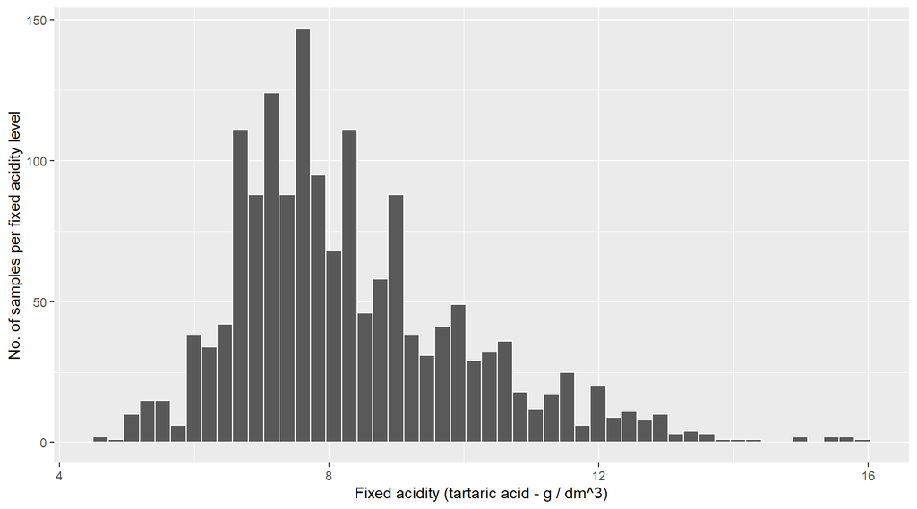

The “Fixed acidity” distribution is right skewed centered around 7.9 Most red wine tend to have relatively low fixed acidity value.

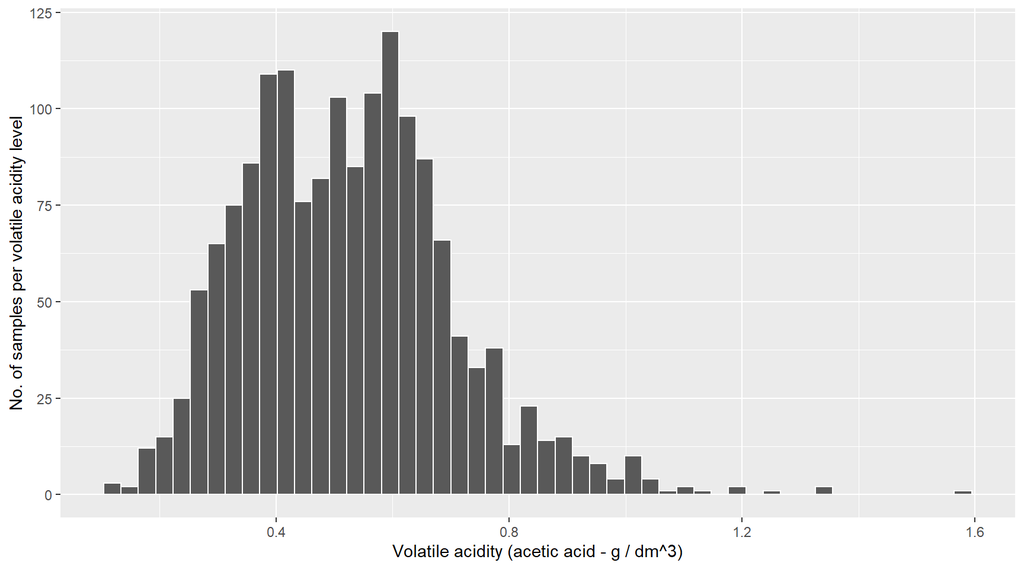

The “Volatile acidity” distribution is right skewed centered around 0.5 Most red wine tend to have relatively low volatile acidity value.

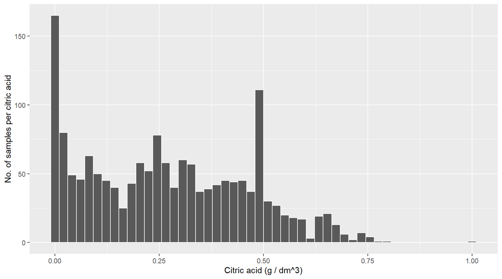

The “Citric acid” distribution doesn’t follow a familiar distribution, and has a few outliers at 1.0 Most red wine either have 0 or 0.5 citric acid, otherwise (the 2 peaks in the graph), otherwise all other values are equally distributed.

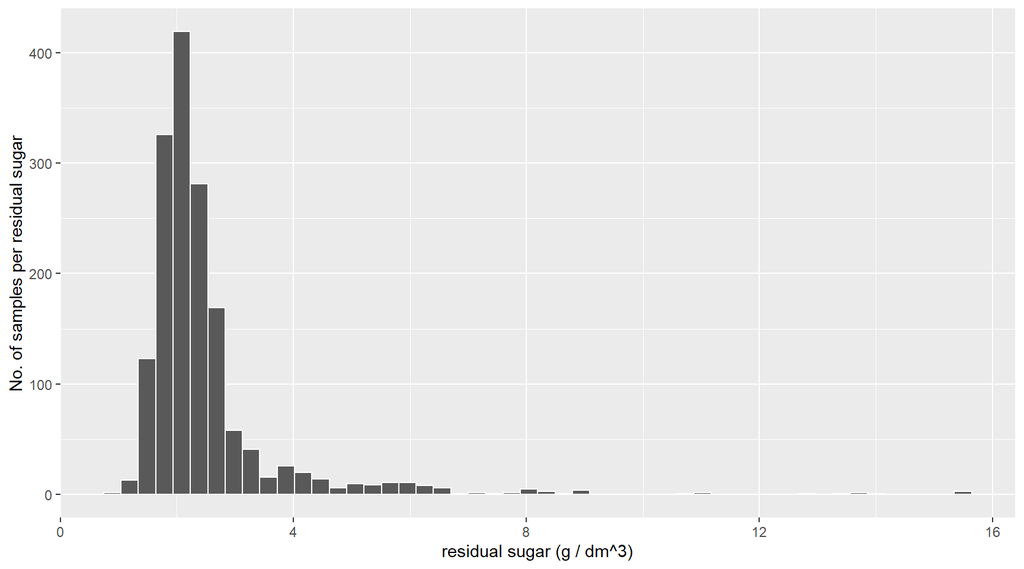

The “Residual sugar” distribution is right-skewed and centered around 2.2 with some outliers. Most red wines tend to have “residual sugar” values from 1 to 3. With few samples otherwise.

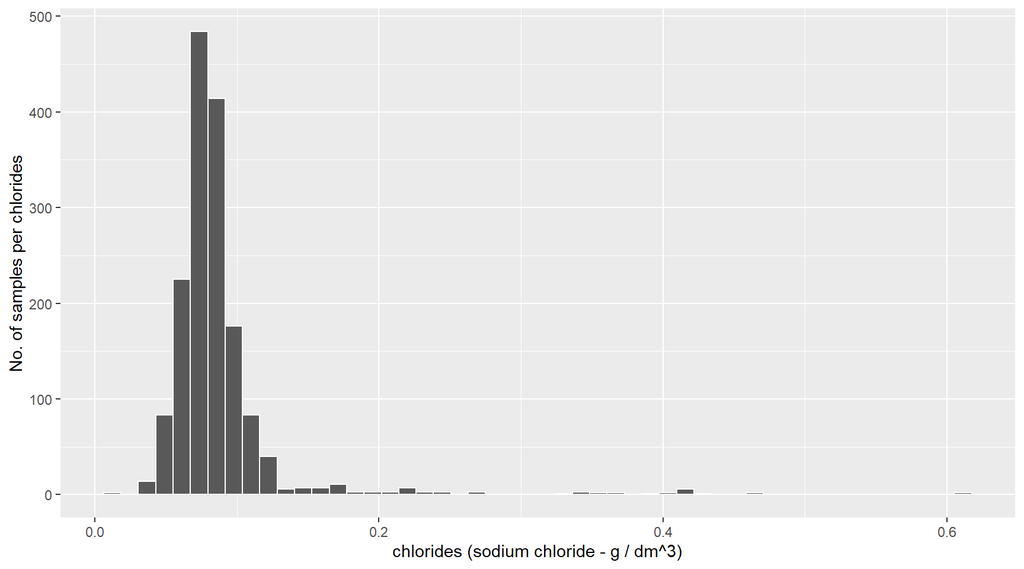

The “Chlorides” distribution is right-skewed and centered around 0.079 with many outliers.

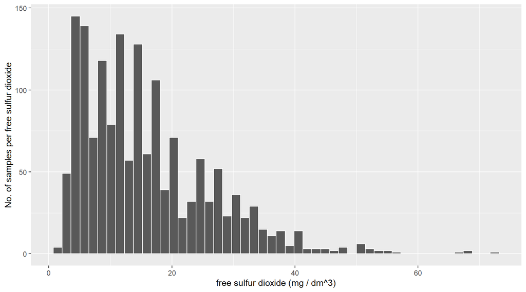

The “Free sulfur dioxide” distribution is right-skewed and centered around 14.0 with many outliers.

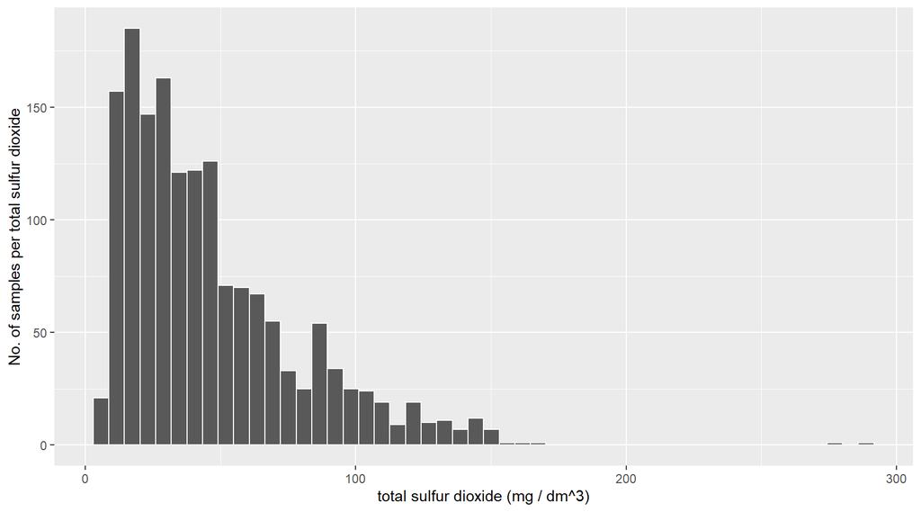

The “Total sulfur dioxide” distribution is right-skewed and centered around 38.0 with few outliers.

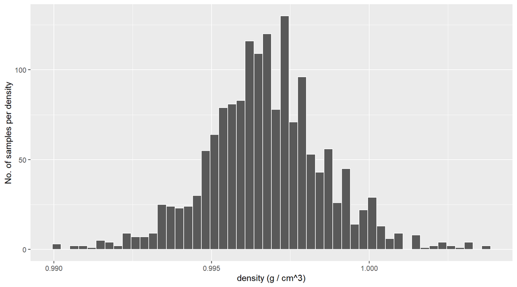

The “Density” distribution is a normal distribution and centered around 0.9968 with few outliers.

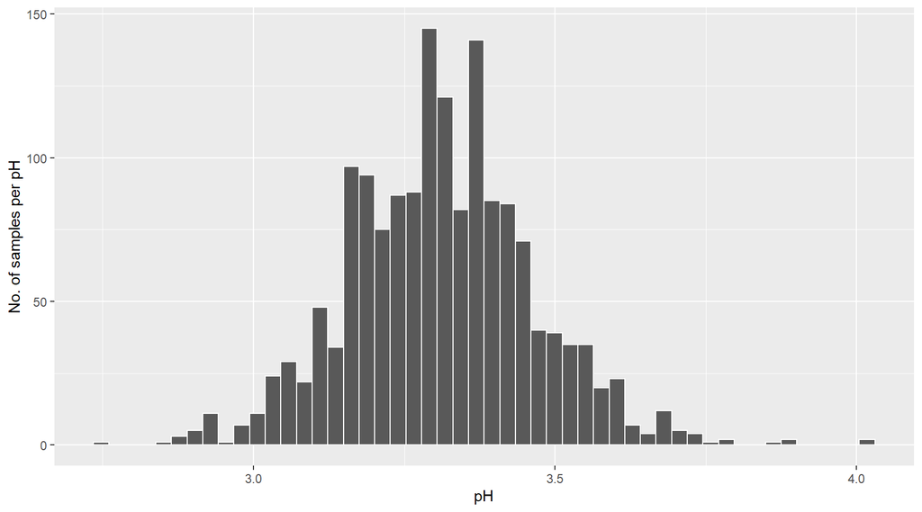

The “pH” distribution is a normal distribution and centered around 3.31 with few outliers. Most red wines tend to balance between acidity and alkanility, so the graph shows a normal distribution.

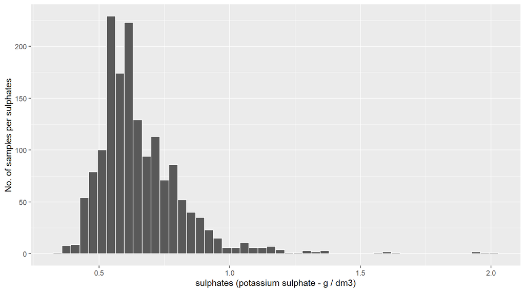

The “Sulphates” distribution is right-skewed distribution and centered around 0.62 with few outliers.

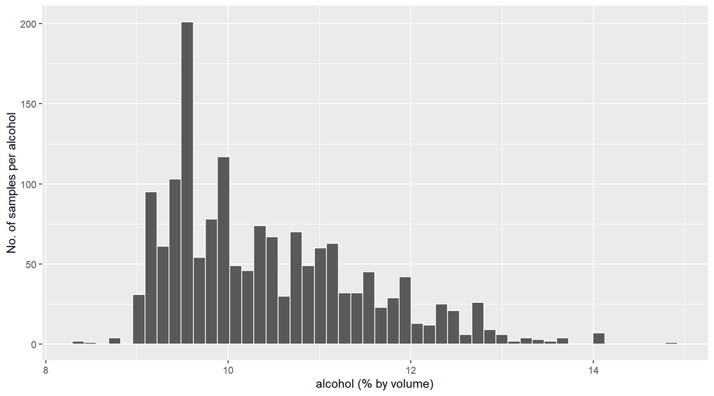

The “alcohol” distribution is almost right-skewed distribution and centered around 10.2 with few outliers.

As expected, very low alcohol % is not preferred (otherwise it would be a normal beverage), so the first part of the graph is empty. Also very high alcohol % is not common because it is too strong to be drunk, so the graph shows a right-skewed distribution with very low alcohol % not available.

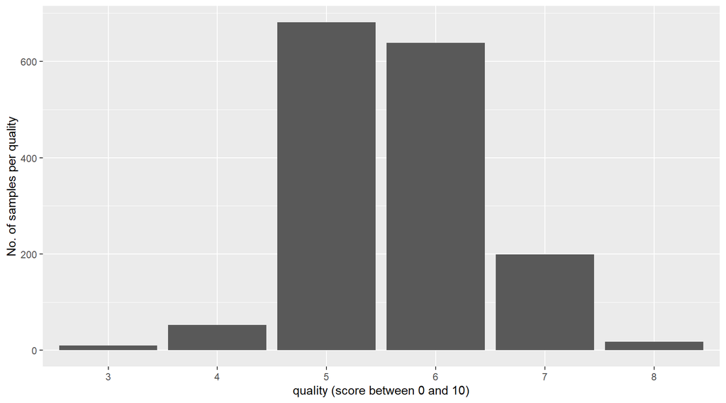

The “quality” distribution is a normal distribution and centered around 6. Most red-wine are of moderate quality, no red wines below quality of 3 and above quality of 8, with most wines ranging between 5 & 6.

# Univariate Analysis

### What is the structure of your dataset?

There are 1,599 red wines in the dataset with 12 vairables describing the different checmical combinations of the wine (Fixed acidity, Volatile acidity, Citric Acid, Residual Sugar, Chlorides, Free Sulphur Dioxide, Total Sulphur Dioxide, Density, pH, Sulphates, Alcohol, Quality).

Other observations:

Most red-wines have quality 5 or 6 (Medium quality).

Most red-wines have alcohol % around 10%

Most red-wines have a balance between aciditiy and alkanility (pH follows a normal distribution).

### What is/are the main feature(s) of interest in your dataset?

The main features in the data set are alcohol and quality I’d like to determine which features are best for predicting the quality of a red-wine. I suspect alcohol and some combination of the other variables can be used to build a predictive model to quality of a red-wine.

### What other features in the dataset do you think will help support your investigation into your feature(s) of interest?

pH, residual sugar and fixed acidity likely contribute to the quality of a red-wine. I think pH and residual sugar probably contribute most to the quality.

### Of the features you investigated, were there any unusual distributions? Did you perform any operations on the data to tidy, adjust, or change the form of the data? If so, why did you do this?

Apart from some few outliers in some variables, there were no unusual distributions, thus I didn’t need to tidy the data.

# Bivariate Plots Section

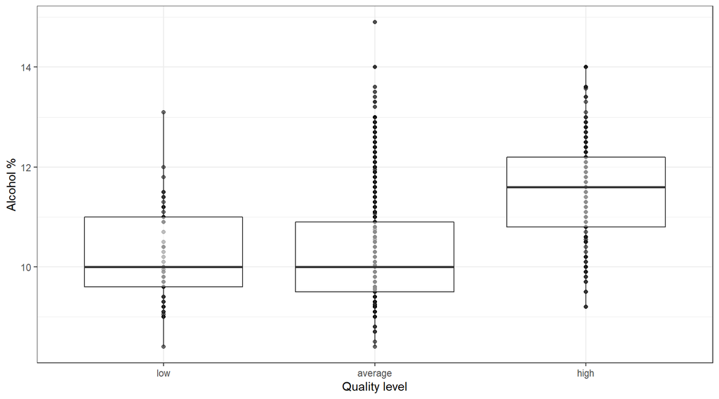

```
##
##  Pearson's product-moment correlation
##
## data:  red_wine_df$quality and red_wine_df$alcohol
## t = 21.639, df = 1597, p-value < 2.2e-16
## alternative hypothesis: true correlation is not equal to 0
## 95 percent confidence interval:
##  0.4373540 0.5132081
## sample estimates:
##       cor
## 0.4761663
```

The graph shows that the higher the Alcohol %, the higher the quality of red-wine. For Low and Medium qualities, the alcohol level is around 10%, while for High quality, the alcohol level is higher. Therefore there’s a correlation between alcohol level and the quality of wine. This is further confirmed by the Pearson correlation coefficient of 0.476 showing a positive relationship between Alcohol % and Quality of wine.

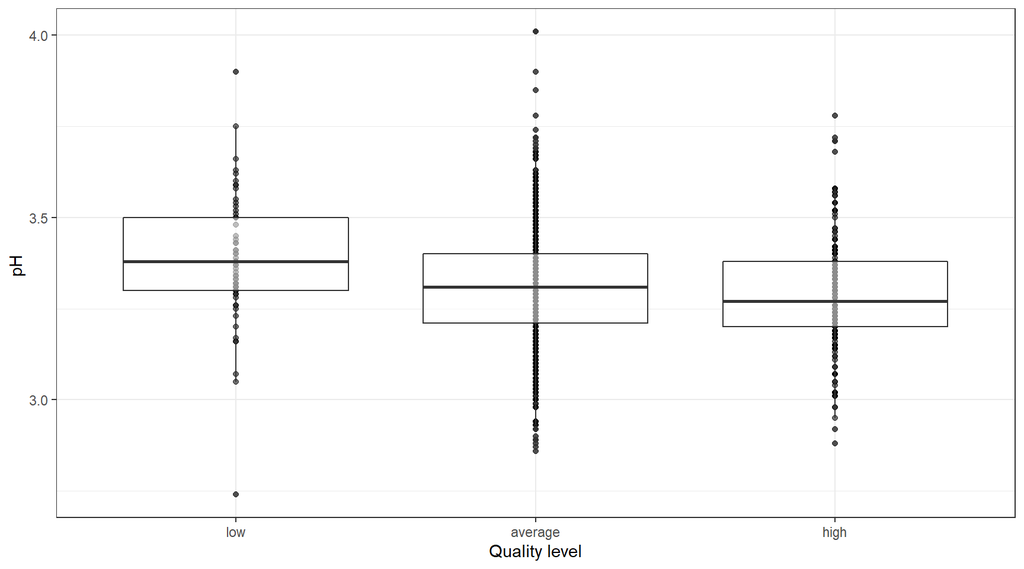

```
##
##  Pearson's product-moment correlation
##
## data:  red_wine_df$quality and red_wine_df$pH
## t = -2.3109, df = 1597, p-value = 0.02096
## alternative hypothesis: true correlation is not equal to 0
## 95 percent confidence interval:
##  -0.106451268 -0.008734972
## sample estimates:
##         cor
## -0.05773139
```

The graph shows a weak inverse correlation between pH and the wine quality, the higher the pH, the lower the quality. This weak correlation is confirmed by Pearson correlation coefficient of -0.057.

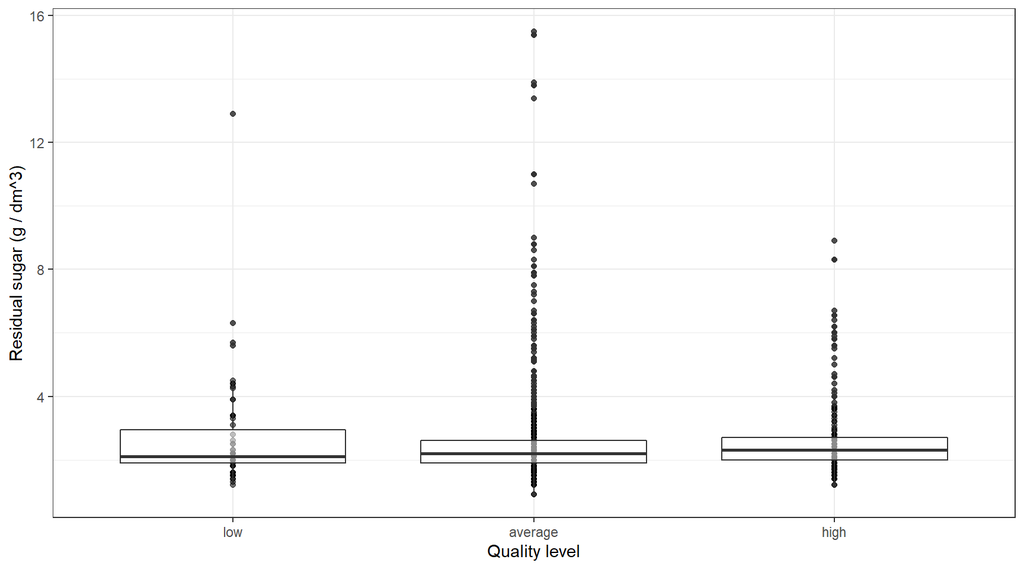

```
##
##  Pearson's product-moment correlation
##
## data:  red_wine_df$quality and red_wine_df$residual.sugar
## t = 0.5488, df = 1597, p-value = 0.5832
## alternative hypothesis: true correlation is not equal to 0
## 95 percent confidence interval:
##  -0.03531327  0.06271056
## sample estimates:
##        cor
## 0.01373164
```

Both the graph and the pearson correlation coefficient shows a weak correlation between the wine quality and the residual sugar.

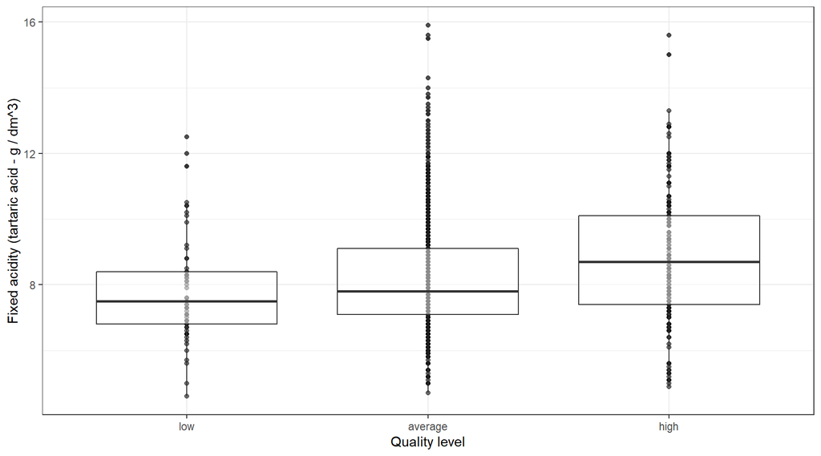

```
##
##  Pearson's product-moment correlation
##
## data:  red_wine_df$quality and red_wine_df$fixed.acidity
## t = 4.996, df = 1597, p-value = 6.496e-07
## alternative hypothesis: true correlation is not equal to 0
## 95 percent confidence interval:
##  0.07548957 0.17202667
## sample estimates:
##       cor
## 0.1240516
```

Both the graph and the pearson correlation coefficient shows a weak correlation between the wine quality and the fixed acidity.

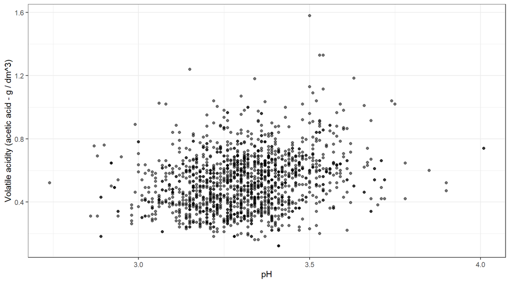

```
##
##  Pearson's product-moment correlation
##
## data:  red_wine_df$pH and red_wine_df$volatile.acidity
## t = 9.659, df = 1597, p-value < 2.2e-16
## alternative hypothesis: true correlation is not equal to 0
## 95 percent confidence interval:
##  0.1880823 0.2807254
## sample estimates:
##       cor
## 0.2349373
```

The graph shows a weak positive correlation between pH and volatile acidity, that makes sense, because pH refers to the percentage of acidity to alkalinility, so the higher the pH, the higher the acidity of the red-wine. The weak positive correlation is confirmed with a Pearson’s correlation coefficient of 0.2349.

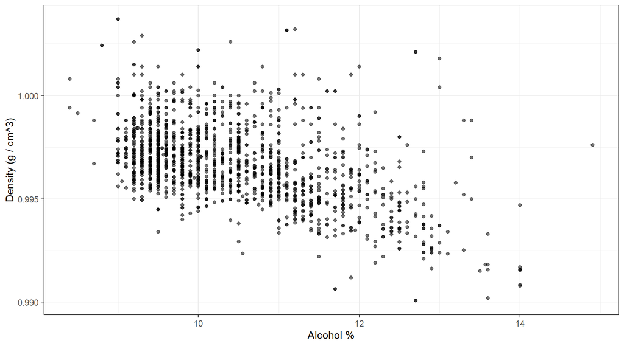

```
##
##  Pearson's product-moment correlation
##
## data:  red_wine_df$alcohol and red_wine_df$density
## t = -22.838, df = 1597, p-value < 2.2e-16
## alternative hypothesis: true correlation is not equal to 0
## 95 percent confidence interval:
##  -0.5322547 -0.4583061
## sample estimates:
##        cor
## -0.4961798
```

The graph shows a strong negative correlation between Alcohol % and Density, because the juice density is higher than alcohol density, so the higher the alcohol %, the lower the juice %, and the lower the total density of wine. This is confirmed with a Pearson correlation coefficient of -0.496.

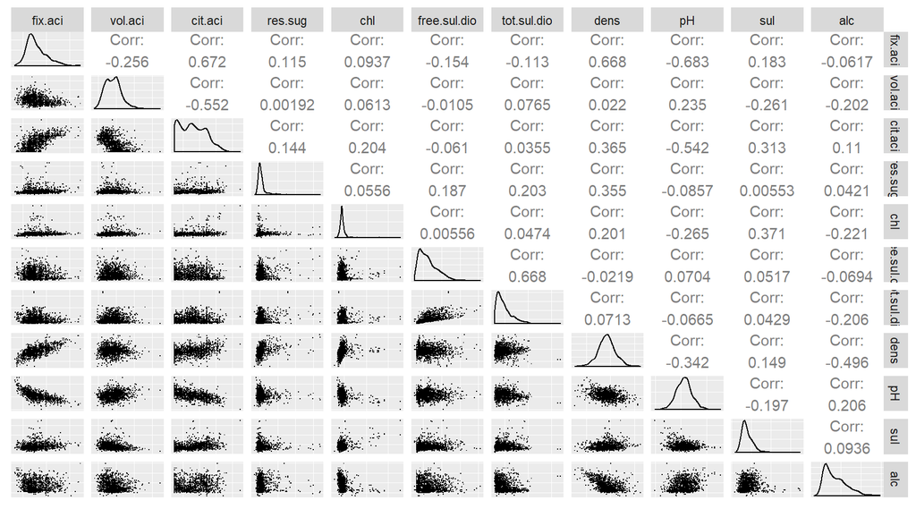

The graph above shows the following:

- Strong positive relationship between Fixed Acidity & Citric Acid (Coeff. = 0.672).
- Strong negative relationship between Fixed Acidity & pH (Coeff. = -0.683).
- Strong negative relationship between Alcohol % & Density (Coeff. = -0.496).

# Bivariate Analysis

### Talk about some of the relationships you observed in this part of the investigation. How did the feature(s) of interest vary with other features in the dataset?

I observed a strong positive relationship between Alcohol % and wine quality, which makes sense, because people who like to drink wine, dink it because of the alcohol inside it.

There are also some weak relationships between the feature of interest “Quality” and other features like: pH (weak negative), Residual sugar (weak positive), Fixed acidity (weak positive).

For the other feature of interest “Alcohol %”, there is a strong relationships with: Density (Strong negative), and other weak relationships like: Volatile acidity (weak negative), Chlorides (weak negative), Total Sulfur Dioxide (weak negative) and pH (weak positive).

### What was the strongest relationship you found?

The strongest relationship I found was the negative relationship between “pH” and “Fixed Acidity” with a Pearson’s correlation coefficient of -0.683.

That makes sense because the higher the pH, the higher the acidity of wine, the lower the fixed acidity is.

# Multivariate Plots Section

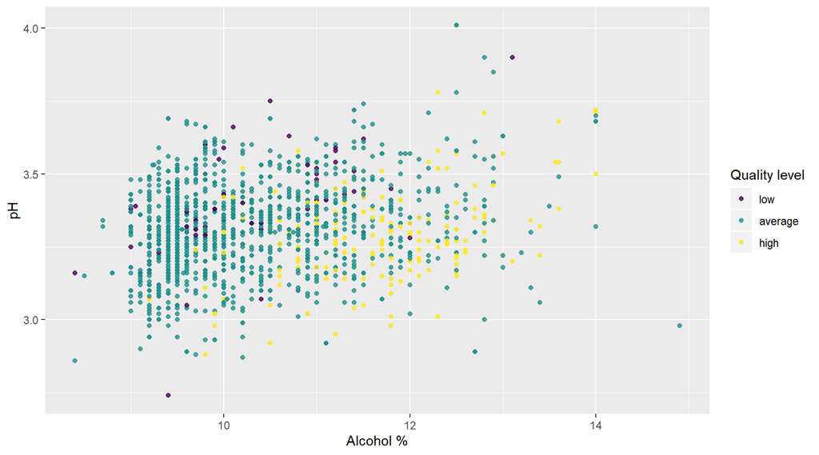

Most high quality wines have “Alcohol %” > 10% and pH level < 3.5. That makes sense because high alcohol % have better qualities, and more acidic wines (higher pH values) are not appealing to the customers.

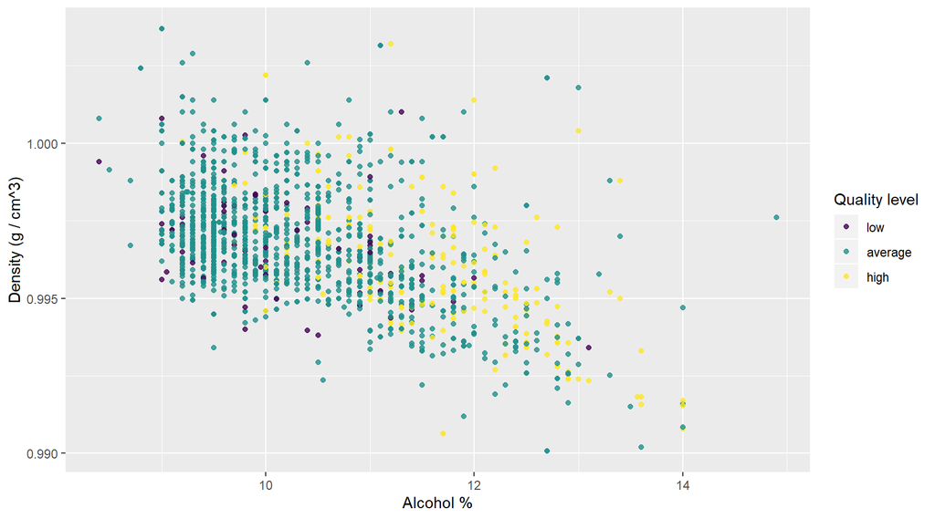

The lower the density, the higher the quality as shown in the plot. Also as known, Alcohol % have a strong positive relationship with the quality.

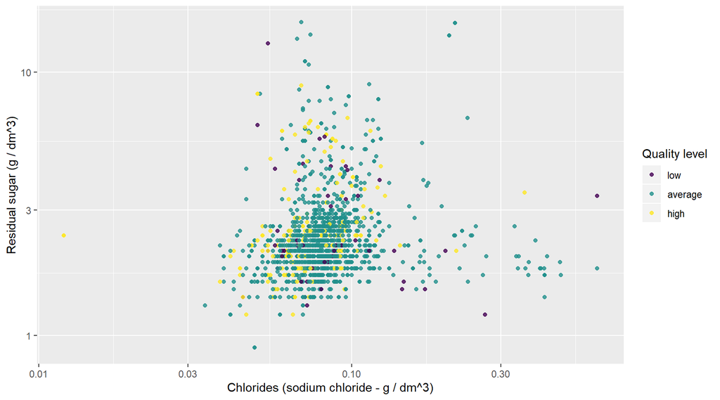

From the plot, it seems the residual sugar and chlorides don’t have a strong influence on the quality.

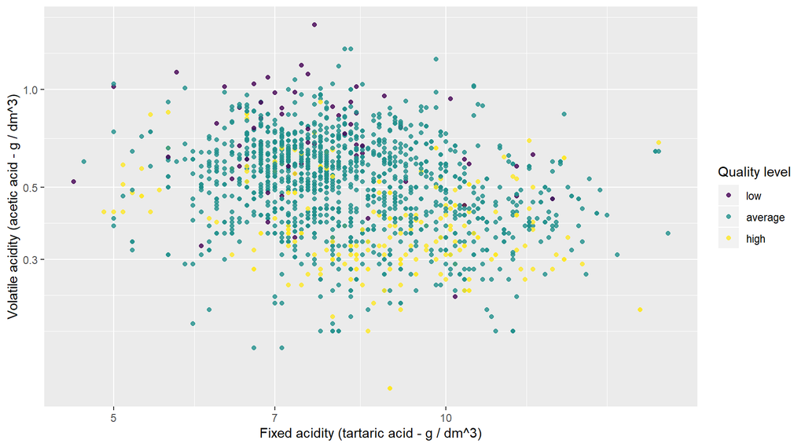

From the graph it seems that fixed acidity and volatile acidity are opposite to each other, increasing fixed acidity will lead to low volatile acidity which means a better quality wine, and vice versa.

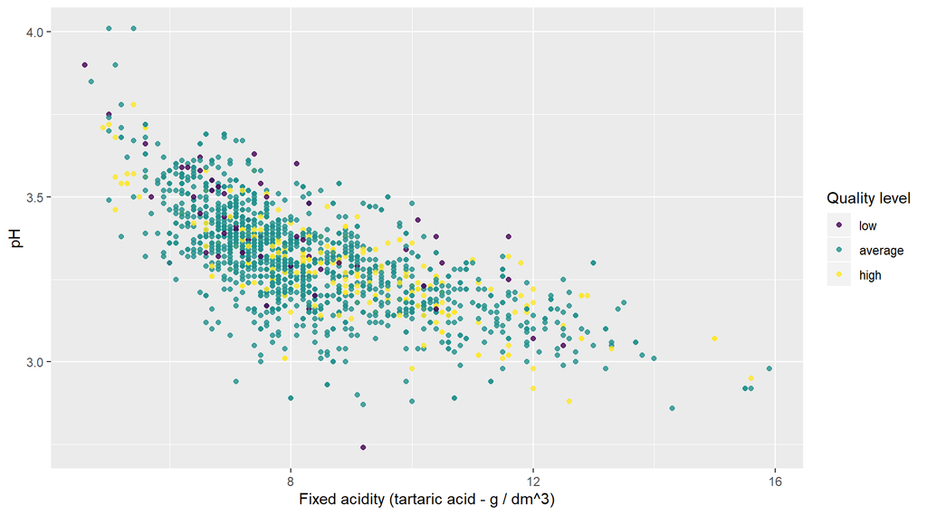

There’s a strong negative relation ship between Fixed acidity and pH value.

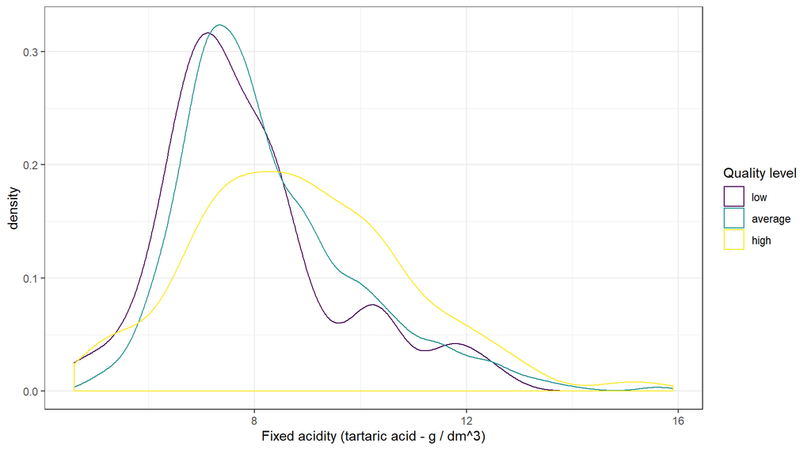

High quality wines seem to be concentrated at “Fixed acidity” between 6 and 9.

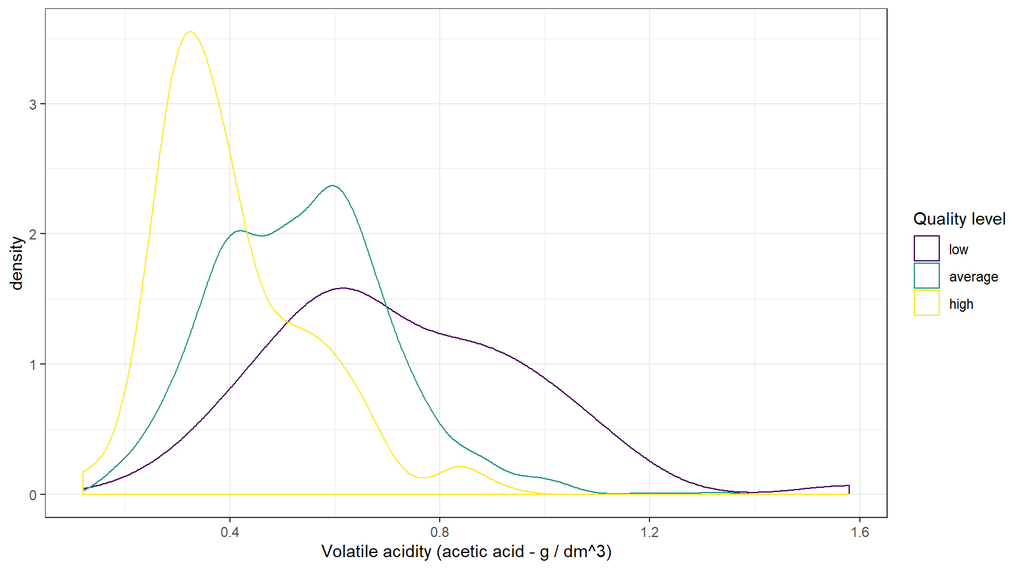

High quality wines seem to be concentrated at “Volatile acidity” between 0.2 and 0.6.

# Multivariate Analysis

### Talk about some of the relationships you observed in this part of the investigation. Were there features that strengthened each other in terms of looking at your feature(s) of interest?

There’s a negative relationship between fixed acidity and volatile acidity.

There’s a strong negative relationship between fixed acidity and pH.

### Were there any interesting or surprising interactions between features?

Residual sugar has almost no impact on the wine quality, I expected that the more sugary the wine is, the better quality it wil be.

# Final Plots and Summary

### Plot One (Count of wines per quality level)

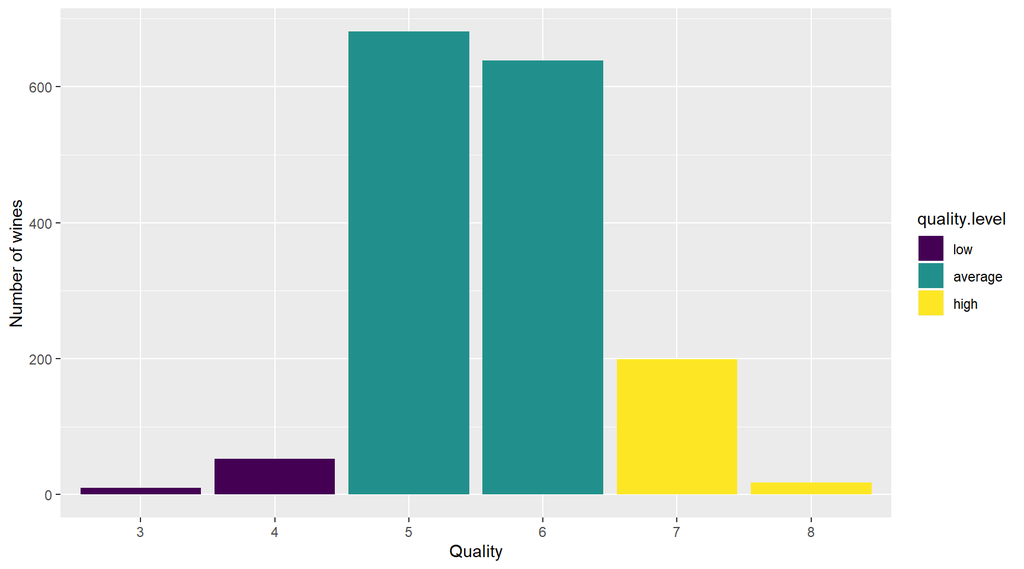

### Description One

The red-wine quality distribution shows a normal distribution. Most of the wines lie in the Average quality. There are no wine samples having quality < 3 or > 8.

### Plot Two (Wine quality level distribution against alcohol %)

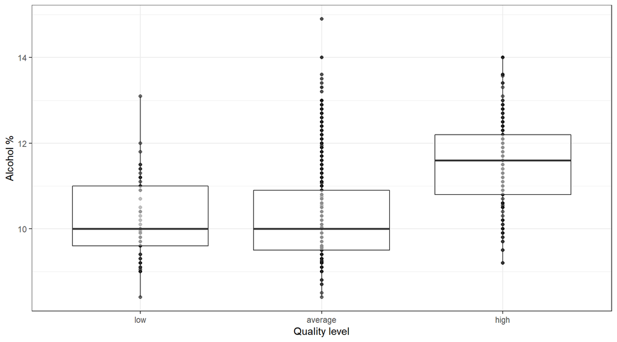

### Description Two

The higher the Alcohol %, the higher the quality of red-wine. For Low and Medium qualities, the alcohol level is around 10%, while for High quality, the alcohol level is higher. Therefore there’s a positive correlation between alcohol level and the quality of wine.

### Plot Three (Wine quality level distribution against alcohol % and pH)

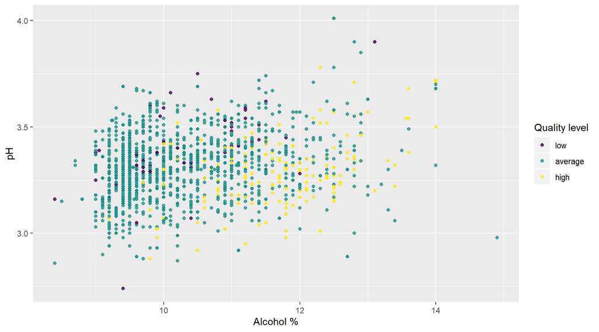

### Description Three

Most high quality wines have “Alcohol %” > 10% and pH level < 3.5. That makes sense because high alcohol % have better qualities, and more acidic wines (higher pH values) are not appealing to the customers.

# Reflection

The red-wine dataset contains 1599 observations with 12 variables described here: https://s3.amazonaws.com/udacity-hosted-downloads/ud651/wineQualityInfo.txt

For simplicity, I added a 13th variable that is called “quality.level” so that I convert the quantative variable “quality” to a categorical variable. (0 –> 4: low, 5 –> 6: average, 7 –> 10: high).

The quality.level of red-wines followed a normal distribution, while other variables like residual sugar and total sulfur dioxide followed a right-skewed distribution.

The important features of interest that I expected to be crucial are the quality.level and the alcohol %. There was a strong positive correlation between these 2 variables.

Also there was a strong negative correlation between Alcohol % and Density, because density of Alcohol is less than density of the juice itself.

The strongest relationship I found was between pH and Fixed acidity, it was a negative correlation.

One of the strangest things I found in my analaysis, is that the sugar level doesn’t affect the quality of the wine, unlike what I thought before the beginning of my analysis.

In my opinion we can improve our analysis if we collect more data, as I believe there are some more factors that may affect the quality of our wine, like the flavor or a secret recipe by the manufacturer.